# Tarea 01

Joshua

Mon May 01 20:48:06 2017

## Evaluación y Consideraciones

Cada grupo deberá enviar un mail a jbkunst@gmail.com con el asunto “Tarea namber wan” (sin comillas) adjuntando un script el cual deberá correr sin errores al ser ejecutado y debe claramente señalar los comandos (esto es el código mismo) con el cual obtuvo las respuestas incluyendo comentarios.

Se evaluará tanto el código como el resultado con comentarios. Con esto se intenta evitar las respuestas *al ojo* o usando otras herramientas como *excel*.

Por ejemplo, supongamos el archivo `script_grupo_1.R`

```
# Pregunta 1
# Para esta pregunta debemos seleccionar filtrar el data frame y segun x > 5
# y reordenar segun la variable y:

data %>%
  filter(x > 5) %>%
  arrange(y)
```

Son libres de hacer preguntas vía mail pero siempre háganlo escribiéndolo a todo el grupo.

Espero los script a **más tardar** el miércoles 26 de este més (y de este año) a las 11.59 PM. Obviamente lo pueden enviar el script más tarde, la única salvedad es que la nota final será la nota por el script dividido por 1.25 por cada hora que pase desde el límite. A modo de ejemplo si la nota es un 5.5, y fue entregado a las 3AM, la nota final será:

```r
nota_script <- 5.5
nota_final <- nota_script/(1.25^3)
round(nota_final, 1)
```

```
## [1] 2.8
```

## Requerimientos

Necesitaremos algunos paquetes para trabajar. El siguiente código instalará lo requerido:

[figure not shown]

```r
library(tidyverse)

paquetes_a_instalar <- c("gapminder", "babynames", "nasaweather",
                         "fueleconomy", "nycflights13", "maps")

for(p in paquetes_a_instalar) {
  message("Instalando ", p)
  if(!p %in% rownames(installed.packages())) install.packages(p)
  library(p, character.only = TRUE)
}
```

## Pregunta 0 (el punto base)

Considere, la tabla `births` del paquete `babynames`. Esto es:

```r
data("births", package = "babynames")
head(births)
```

```
## # A tibble: 6 × 2
##    year  births
##   <int>   <int>
## 1  1909 2718000
## 2  1910 2777000
## 3  1911 2809000
## 4  1912 2840000
## 5  1913 2869000
## 6  1914 2966000
```

¿Cuántas columnas y filas posee la tabla *births*?

### Respuesta

```r
dim(births)
```

```
## [1] 119   2
```

o:

```r
c(filas = nrow(births), columnas = ncol(births))
```

```
##    filas columnas
##      119        2
```

## Pregunta 1

Considere, la tabla `births` del paquete `babynames`. Estudie los nacimientos por años en EE.UU:

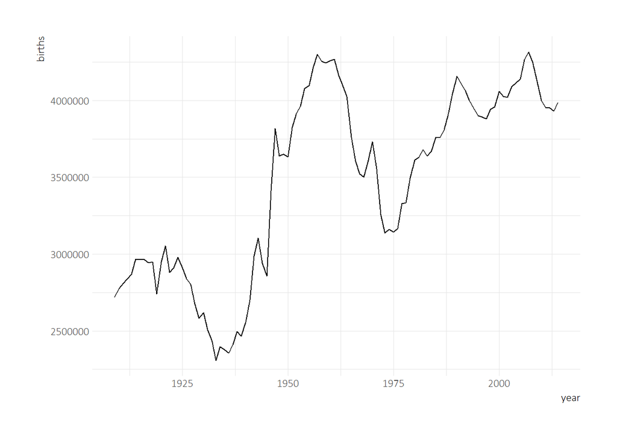

```r
ggplot(births) +
  geom_line(aes(year, births))
```

¿En que *decada* se obtuvo la menor cantidad de nacimientos?.

### Respuesta

```r
births %>%
  mutate(decada = 10 * floor(year/10)) %>%
  group_by(decada) %>%
  summarise(n = n(), births = sum(births)) %>%
  arrange(births)
```

```
## # A tibble: 12 × 3
##    decada     n   births
##     <dbl> <int>    <int>
## 1    1900     1  2718000
## 2    1930    10 24374000
## 3    1920    10 28582000
## 4    1910    10 28822000
## 5    1940    10 31666000
## 6    1970    10 33308000
## 7    1980    10 37508000
## 8    1960    10 38807000
## 9    2010    10 39652148
## 10   1990    10 39860000
## 11   1950    10 40526000
## 12   2000    18 74729448
```

Podría responderse que la decada de los ’00 es la que tiene menos pero está incompleta, un año. Un grupo para remover el 1909 hizo:

```r
births[-c(1),]
```

```
## # A tibble: 118 × 2
##     year  births
##    <int>   <int>
## 1   1910 2777000
## 2   1911 2809000
## 3   1912 2840000
## 4   1913 2869000
## 5   1914 2966000
## 6   1915 2965000
## 7   1916 2964000
## 8   1917 2944000
## 9   1918 2948000
## 10  1919 2740000
## # ... with 108 more rows
```

En lugar de:

```r
filter(births, year >= 1910)
```

```
## # A tibble: 118 × 2
##     year  births
##    <int>   <int>
## 1   1910 2777000
## 2   1911 2809000
## 3   1912 2840000
## 4   1913 2869000
## 5   1914 2966000
## 6   1915 2965000
## 7   1916 2964000
## 8   1917 2944000
## 9   1918 2948000
## 10  1919 2740000
## # ... with 108 more rows
```

Es lo mismo, cierto? Que pasa si la tabla viene en ningún orden en particular?

```r
births <- sample_frac(births, 1) # desorden, desorden, esto es un desorden (8)
births
```

```
## # A tibble: 119 × 2
##     year  births
##    <int>   <int>
## 1   1910 2777000
## 2   1990 4158000
## 3   1942 2989000
## 4   1985 3761000
## 5   2011 3953590
## 6   1939 2466000
## 7   2013 3932181
## 8   1946 3411000
## 9   1986 3757000
## 10  1969 3600000
## # ... with 109 more rows
```

Comparar

```r
births[-c(1),]
```

```
## # A tibble: 118 × 2
##     year  births
##    <int>   <int>
## 1   1990 4158000
## 2   1942 2989000
## 3   1985 3761000
## 4   2011 3953590
## 5   1939 2466000
## 6   2013 3932181
## 7   1946 3411000
## 8   1986 3757000
## 9   1969 3600000
## 10  1923 2910000
## # ... with 108 more rows
```

```r
filter(births, year >= 1910)
```

```
## # A tibble: 118 × 2
##     year  births
##    <int>   <int>
## 1   1910 2777000
## 2   1990 4158000
## 3   1942 2989000
## 4   1985 3761000
## 5   2011 3953590
## 6   1939 2466000
## 7   2013 3932181
## 8   1946 3411000
## 9   1986 3757000
## 10  1969 3600000
## # ... with 108 more rows
```

El `c(1)` no es *explícito*. Prefieran lo explícito antes de lo que no. Segun el *zen de Pytohn*.

```r
# Beautiful is better than ugly.
# Explicit is better than implicit.
# Simple is better than complex.
# Complex is better than complicated.
# Flat is better than nested.
# Sparse is better than dense.
# Readability counts.
# Special cases aren't special enough to break the rules.
# Although practicality beats purity.
# Errors should never pass silently.
# Unless explicitly silenced.
# In the face of ambiguity, refuse the temptation to guess.
# There should be one-- and preferably only one --obvious way to do it.
# Although that way may not be obvious at first unless you're Dutch.
# Now is better than never.
# Although never is often better than *right* now.
# If the implementation is hard to explain, it's a bad idea.
# If the implementation is easy to explain, it may be a good idea.
# Namespaces are one honking great idea -- let's do more of those! _python_ existe
```

## Pregunta 2

Considerando ahora la tabla `babynames` del paquete `babynames`:

```r
data("babynames", package = "babynames")
glimpse(babynames)
```

```
## Observations: 1,858,689
## Variables: 5
## $ year <dbl> 1880, 1880, 1880, 1880, 1880, 1880, 1880, 1880, 1880, 188...
## $ sex  <chr> "F", "F", "F", "F", "F", "F", "F", "F", "F", "F", "F", "F...
## $ name <chr> "Mary", "Anna", "Emma", "Elizabeth", "Minnie", "Margaret"...
## $ n    <int> 7065, 2604, 2003, 1939, 1746, 1578, 1472, 1414, 1320, 128...
## $ prop <dbl> 0.072384329, 0.026679234, 0.020521700, 0.019865989, 0.017...
```

Realice el proceso necesario para obtener el mismo estructura en cuanto a *columnas* que la tabla `births`.

### Respuesta

Esta respuesta se anuló dado que solo un grupo supo responder lo que yo *intenté* pedir. Seguramente no fui explícito en lo que quería por lo que esta pregunta no suma ni resta puntos en la nota final de la tarea.

```r
babynames %>%
  group_by(year) %>%
  summarize(births = sum(n))
```

```
## # A tibble: 136 × 2
##     year births
##    <dbl>  <int>
## 1   1880 201482
## 2   1881 192696
## 3   1882 221534
## 4   1883 216945
## 5   1884 243463
## 6   1885 240854
## 7   1886 255319
## 8   1887 247396
## 9   1888 299474
## 10  1889 288948
## # ... with 126 more rows
```

## Pregunta 3

Genere un data frame partiendo de la tabla babyanes `babynames` y conteniendo los nacimientos de personas de género femenino con el nombre *Nala*, *Ariel* y *Elsa* desde los años 1980 en adelante.

### Respuesta

```r
bbnames2 <- babynames %>%
  filter(sex == "F") %>%
  filter(name %in% c("Nala", "Ariel", "Elsa")) %>%
  filter(year >= 1980)
bbnames2
```

```
## # A tibble: 94 × 5
##     year   sex  name     n         prop
##    <dbl> <chr> <chr> <int>        <dbl>
## 1   1980     F  Elsa   243 0.0001364994
## 2   1980     F Ariel   181 0.0001016724
## 3   1981     F  Elsa   241 0.0001347851
## 4   1981     F Ariel   228 0.0001275145
## 5   1982     F Ariel   584 0.0003219909
## 6   1982     F  Elsa   206 0.0001135790
## 7   1983     F Ariel   650 0.0003633101
## 8   1983     F  Elsa   235 0.0001313506
## 9   1984     F Ariel   636 0.0003528274
## 10  1984     F  Elsa   216 0.0001198282
## # ... with 84 more rows
```

## Pregunta 4

Con el data frame obtenido en la pregunta anterior genere un gráfico que contenga la información de los nacimientos por año de cada uno de los nombres mencionados y **mencione** una hipótesis/suposición al respecto de lo observado.

hint: Use `facet_wrap(~ name, scales = "free_y")`.

### Respuesta

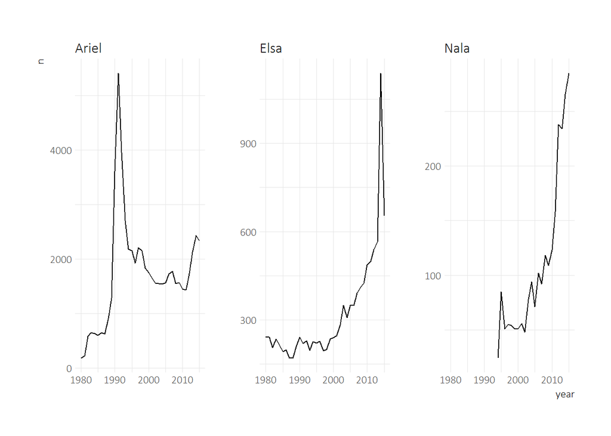

```r
ggplot(bbnames2) +
  geom_line(aes(year, n)) +
  facet_wrap(~ name, scales = "free_y")
```

Recuerden, todo puede ser *pior*.

[figure not shown]

## Pregunta 5

Utilizando la tabla `airports` y `flights` del paquete `nycflights13` obtenga una tabla que contenga conteos de vuelos según su destino además de la longitud y latidud del aeropuerto (de destino).

### Respuesta

```r
data("airports", package = "nycflights13")
data("flights", package = "nycflights13")

airprts2  <- flights %>%
  count(faa = dest) %>%
  left_join(airports)

airprts2
```

```
## # A tibble: 105 × 9
##      faa     n                              name      lat        lon   alt
##    <chr> <int>                             <chr>    <dbl>      <dbl> <int>
## 1    ABQ   254 Albuquerque International Sunport 35.04022 -106.60919  5355
## 2    ACK   265                     Nantucket Mem 41.25305  -70.06018    48
## 3    ALB   439                       Albany Intl 42.74827  -73.80169   285
## 4    ANC     8        Ted Stevens Anchorage Intl 61.17436 -149.99636   152
## 5    ATL 17215   Hartsfield Jackson Atlanta Intl 33.63672  -84.42807  1026
## 6    AUS  2439             Austin Bergstrom Intl 30.19453  -97.66989   542
## 7    AVL   275        Asheville Regional Airport 35.43619  -82.54181  2165
## 8    BDL   443                      Bradley Intl 41.93889  -72.68322   173
## 9    BGR   375                       Bangor Intl 44.80744  -68.82814   192
## 10   BHM   297                   Birmingham Intl 33.56294  -86.75355   644
## # ... with 95 more rows, and 3 more variables: tz <dbl>, dst <chr>,
## #   tzone <chr>
```

## Pregunta 6

Apoyándose del siguiente gráfico

```r
us <- map_data("state")

glimpse(us)
```

```
## Observations: 15,537
## Variables: 6
## $ long      <dbl> -87.46201, -87.48493, -87.52503, -87.53076, -87.5708...
## $ lat       <dbl> 30.38968, 30.37249, 30.37249, 30.33239, 30.32665, 30...
## $ group     <dbl> 1, 1, 1, 1, 1, 1, 1, 1, 1, 1, 1, 1, 1, 1, 1, 1, 1, 1...
## $ order     <int> 1, 2, 3, 4, 5, 6, 7, 8, 9, 10, 11, 12, 13, 14, 15, 1...
## $ region    <chr> "alabama", "alabama", "alabama", "alabama", "alabama...
## $ subregion <chr> NA, NA, NA, NA, NA, NA, NA, NA, NA, NA, NA, NA, NA, ...
```

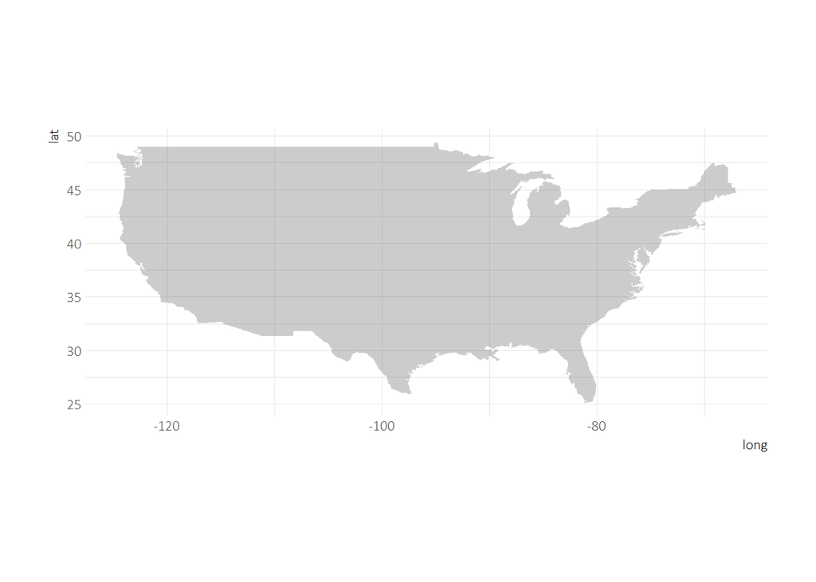

```r
ggmap <- ggplot() +
  geom_polygon(data = us, aes(long, lat, group = group),
               alpha = 0.25) +
  coord_fixed() # esto es para mantener la razón 1:1

ggmap
```

Agregue una capa de de puntos ubicando los aeropuertos obtenidos de la pregunta anterior y usando además: `aes(size = la_cantidad_de_vuelos_a_dicho_aeropuerto)`.

### Respuesta

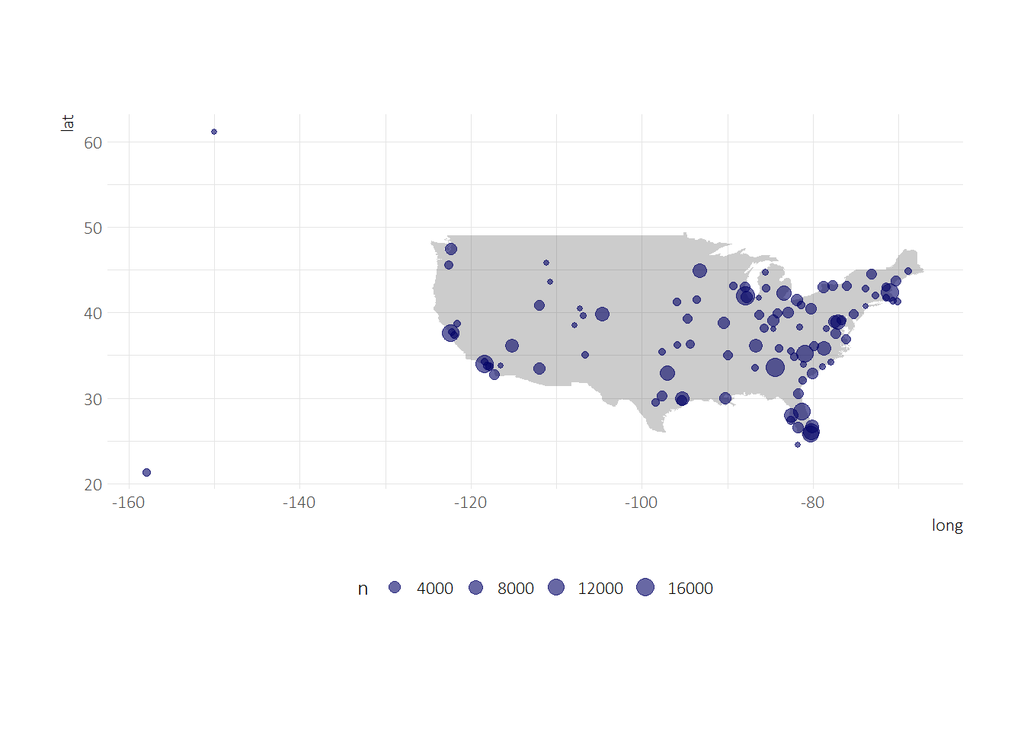

```r
ggmap +
  geom_point(data = airprts2, aes(lon, lat, size = n),
             alpha = 0.6, color = "#030367")  + # a lo grupo 2
  scale_size_continuous(range = c(1, 4)) # a lo grupo 1
```

## Pregunta 7

A la izquiera del gráfico anterior se observan 2 puntos. Genere el/los pasos necesarios para seleccionarlos usando la tabla resultante de la pregunta 5 para identificar los nombres de dichos areopuertos y responda ¿Dónde están? ¿Que gracias tienen?

### Respuesta

Gracia? Que están *leeejos*.

```r
filter(airprts2, lon <= -140)
```

```
## # A tibble: 2 × 9
##     faa     n                       name      lat       lon   alt    tz
##   <chr> <int>                      <chr>    <dbl>     <dbl> <int> <dbl>
## 1   ANC     8 Ted Stevens Anchorage Intl 61.17436 -149.9964   152    -9
## 2   HNL   707              Honolulu Intl 21.31868 -157.9224    13   -10
## # ... with 2 more variables: dst <chr>, tzone <chr>
```

## Pregunta 8

Considere la tabla `vehicles` del paquete `fueleconomy`.

Genere un subconjunto de la tabla `vehicles` considerando las 10 clases (columna `class`) más comunes y:

1. Genere un gráfico de densidades del consumo en carretera (`hwy`) separando por clase de vehículo.
2. Averigué como usar la función `geom_boxplot` para comparar las distribuciones de rendimiento según clase.

### Respuesta

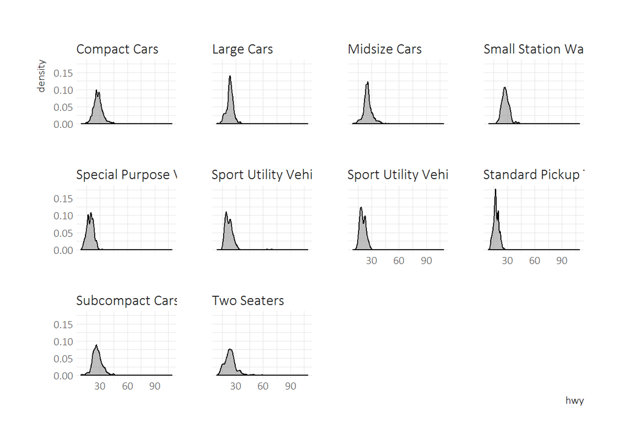

```r
data("vehicles", package = "fueleconomy")

vehicles2 <- vehicles %>%
  count(class) %>%
  arrange(desc(n)) %>%
  top_n(10) %>%
  semi_join(vehicles, .)

ggplot(vehicles2) +
  geom_density(aes(hwy), fill = "gray50", alpha = 0.5) +
  facet_wrap(~class)
```

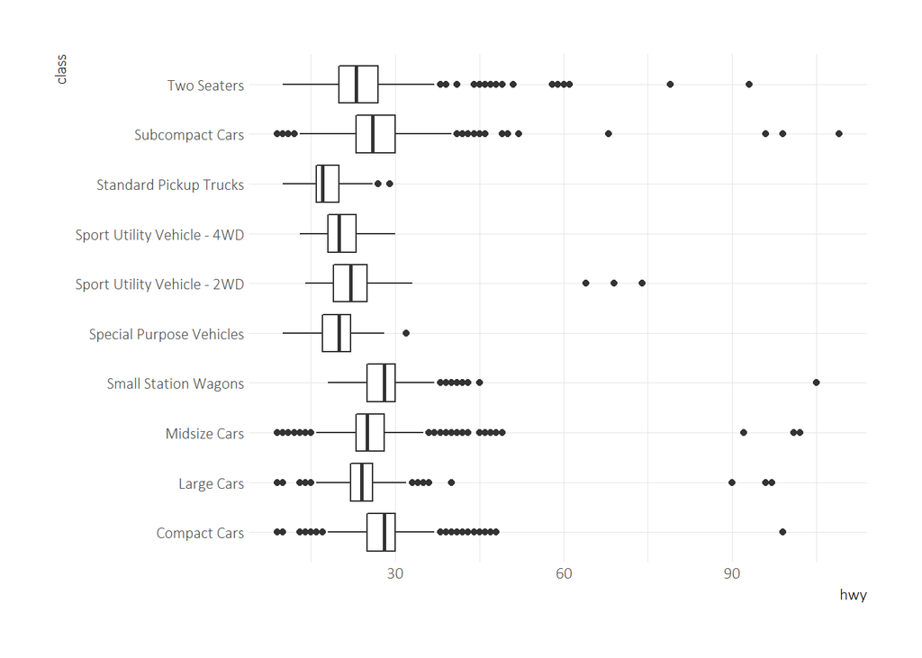

```r
ggplot(vehicles2) +
  geom_boxplot(aes(x = class, y = hwy)) +
  coord_flip() # a lo equipo 5
```

## Pregunta 9

Con los gráficos anteriormente obtenido argumente cuales son las debidildades y fortalezas de cada tipo de visualización.

### Respuesta

Muchas respuestas posibles, todo depende del caso particular. No hay *verdad* absoluta, por lo que nada es verdad, ¿verdad?.

## Pregunta 10

### Respuesta

```r
vehicles2 %>%
  group_by(class) %>%
  summarise(
    n = n(),
    min(hwy), max(hwy)
  )
```

```
## # A tibble: 10 × 4
##                          class     n `min(hwy)` `max(hwy)`
##                          <chr> <int>      <int>      <int>
## 1                 Compact Cars  4739          9         99
## 2                   Large Cars  1533          9         97
## 3                 Midsize Cars  3621          9        102
## 4         Small Station Wagons  1295         18        105
## 5     Special Purpose Vehicles  1453         10         32
## 6  Sport Utility Vehicle - 2WD  1626         14         74
## 7  Sport Utility Vehicle - 4WD  2091         13         30
## 8       Standard Pickup Trucks  2354         10         29
## 9              Subcompact Cars  4185          9        109
## 10                 Two Seaters  1602         10         93
```